# Pisa 2012 Survey

## by (Mostafa El-mallah)

## Investigation Overview

> We are to explore the Dataset and examin the relationships between variables and the three main Target features; Mathematics, Reading and Science scores.

## Dataset Overview

> The data consists of information regarding 485,490 students, including Gender, country, class size, ICT possessions , learning times and habits, subjective norms about studying math and 3 main Test scores for Mathematics, reading language, and Science. The dataset can be found in the PISA survey page  
> [here](https://www.google.com/url?q=https://s3.amazonaws.com/udacity-hosted-downloads/ud507/pisa2012.csv.zip&sa=D&ust=1554482573645000), with feature documentation available [here](https://www.google.com/url?q=https://s3.amazonaws.com/udacity-hosted-downloads/ud507/pisadict2012.csv&sa=D&ust=1554482573645000)

## Distribution of the 3 scores

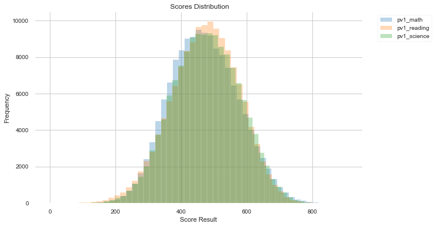

```python
# plotting the 3 Variables of interest
# the math score distribution
main_interest = ['pv1_math','pv1_reading' ,'pv1_science']
plt.figure(figsize=(10,6))
for series in main_interest:
    main_df[series].plot(kind="hist", alpha=0.3, bins=50, title=" Scores Distribution");
plt.legend(bbox_to_anchor=(1.04,1), loc="upper left")
plt.xlabel("Score Result")

plt.show()
```

## Gender Distribution

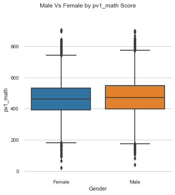

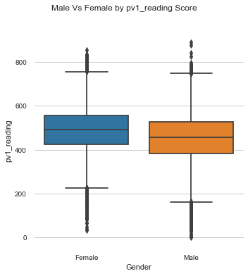

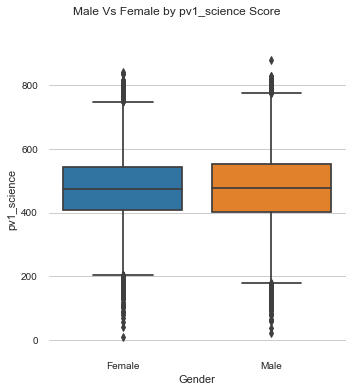

```python
# Visualize Gender differences
main_score_by_gender = main_df[['Gender', 'pv1_math', "pv1_reading", "pv1_science"]]

scores =['pv1_math', "pv1_reading", "pv1_science"]
for score in scores:
         g=sns.catplot(x="Gender", y=score, kind="box", dodge=False, data=main_score_by_gender);
         for title in scores:
                g.fig.suptitle("Male Vs Female by %s Score"%score, y=1.08)
```

## Gender and Scores

We Notice here the strong relation between three scores, this can imply that when a student performs well on one test score, he will likely to have a good score in the other 2 as well,, We also observe the slight performance difference between females and males as previously shown.

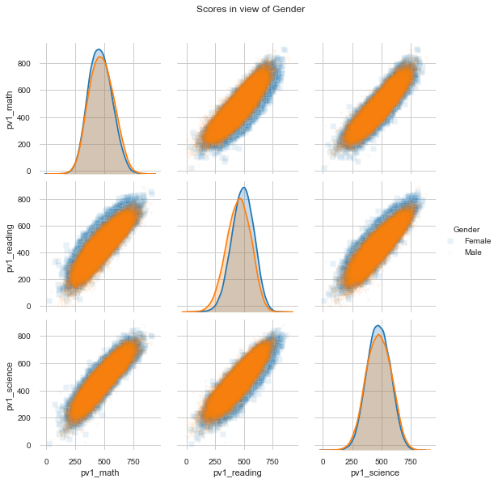

```python
# Does gender has effect on score
plt.figure(figsize=(10,6))
g=sns.pairplot(main_score_by_gender, hue='Gender', height=2.5, plot_kws={'alpha':0.1}, markers=[',',"1"]);
g.fig.suptitle("Scores in view of Gender", y=1.08)
```

## Score by Country

##### We notice that there are several countries which shows in the top 10 countries repeatedly in the 3 scores, interestingly Asian countries have a strong presence in all 3 scores, they must be doing something different, to have such consisetant high scores.

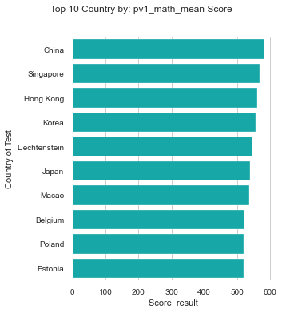

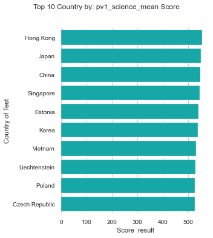

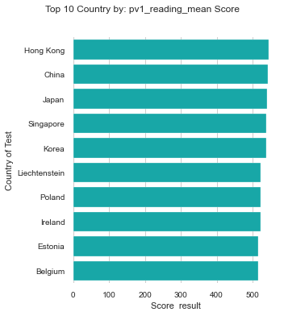

```python
# top scoring countries
mean_score = ['pv1_math_mean', 'pv1_science_mean', 'pv1_reading_mean']

for mean_score in mean_score:
    g=sns.catplot(y='country', x='vals',\
              data=melted_main_group_country.query('score== @mean_score') \
           , kind='bar'\
           ,order=melted_main_group_country.\
                query('score== @mean_score').sort_values(by='vals', ascending=False).iloc[:10]['country'],
               color="c")
    g.set(xlabel='Score  result', ylabel='Country of Test')
    g.fig.suptitle("Top 10 Country by: %s Score"%mean_score, y=1.08)
```

## Score map

```python
# choropleth visualization for easier grasp of scores.
score_mean = ['pv1_science_mean'\
                                         ,"Science_learning_time(min per week)_mean","students_per_class_mean" ]
for score in score_mean:
    score_per_country(country_mean_score, 'country_code', score,'country',score, score)
```

[interactive chart not shown]

## Difference traits of Subjective norms

It seems Chinese parents compared to parents from the oher countries are less likely to put more emphasize for learning math, and perhaps Chinese students out of their own will and desire like Math, that's why they excel at it. or it could be that non chinese parents put social pressure on their children to learn math, that's why these student perform lower than Chinese students.

These asumptions might need deeper investigation with suitable data, for a solid and judgment.

```python
for series in main_df.columns.tolist()[25:28]:
    visualize(china_df, mid_score_countries, series)
```

[interactive chart not shown]